# HW2-EDA with R - Part1: Plotting

Priyanka Ramesh and Shalini Prabhakar

February 11, 2018

## Step 1 - Familiarize yourself with the data and the assignment

In this assignment you’ll do some exploratory data analysis with R on a dataset US census information based on the [American Community Survey](https://www.census.gov/programs-surveys/acs/). The version of this data that we’ll be using is from a Kaggle dataset. See https://www.kaggle.com/muonneutrino/us-census-demographic-data/data and look at the column metadata for the county level table to see what the various columns mean.

As we did in class, you’ll be creating an R Markdown document to both prepare a dataset and do some analysis as well as to document the steps you did (and answer some questions I’ll throw at you).

You’ll notice a few “Hacker Extra” tasks thrown in. These are for those of you who want to go a little above and beyond and attempt some more challenging tasks. And, feel free to do a some free form Hacker Extra style work yourself - in other words, do something beyond what was asked. You’ll learn more.

## Step 2 - Create a new R Markdown document

Save this file as a new R Markdown document and name it **HW2_EDAwR_[*your last name*].Rmd**. Mine would be called **HW2_EDAwR_isken.Rmd**. Save it into the same folder as this file.

This will be your working directory.

Create a new R Project based on this working directory.

**Hacker Extra** - Put this project folder under version control using git. Only track the .R file, the .Rmd file and your .gitignore file. Create a remote repo for this homework assignment in your GitHub account. Periodically push your commits to GitHub. When done with the assignment, paste in the URL of your GitHub project so that I can go look at it.

# Please refer to the hw_2files folder to view the commits by Priyanka and Shalini

# 1. https://github.com/pramesh30/PCDA

# 2. https://github.com/shaliniprabhakar/PCDA-Plotting

## Step 3 - Set working directory and explore data folder

Set the working directory or create an R Studio project in the current folder. You’ll notice that there is a folder named **data**. Inside of it you’ll find the data files for this assignment:

- **acs2015_census_tract_data.csv**
- **acs2015_county_data.csv**
- **us_census_bureau_regions_and_divisions.csv**
- **county.csv**
- **county_MI.csv**

The first two files are from the Kaggle site for this dataset. The two files, **county.csv** and **county_MI.csv**, are files that I created. The first contains county level data from all states and the other just data from Michigan. The R script, **census_data_prep.R** was used to create these files and to merge information from the **us_census_bureau_regions_and_divisions.csv** file with the county data.

You might want to use shell commands or a text editor like Geany to snoop the files a bit.

## Step 4 - Complete the following R tasks and answer questions

Now you’ll need to complete the following tasks in R. Just like we did in class, you should use a combination of markdown text (be concise, no need to write tons of text) to explain what you are doing and R code chunks to actually do it. When you are done, use the “Knit” button to generate an HTML file from your R Markdown. You’ll be submitting BOTH the completed R Markdown file as well as the generated HTML file. You’ll notice that I’ve left some empty code chunks as well as some partially filled in code chunks. Of course, feel free to add more code chunks as needed.

Let’s load a few libraries we’ll need:

```r
library(dplyr)
```

```r
library(ggplot2)
```

### Problem 1 - Get the data into a dataframe

You should read the **county.csv** file into a data frame named county_df and **county_MI.csv** into a data frame named county_MI.

```r
county_df <- read.csv("data/county.csv")
county_MI <- read.csv("data/county_MI.csv")
```

Check the structure of each data.frame and use the `summary` function to begin exploring the data. Are there any NA values? What differences do you notice between the structure of the two data frames.

There are some NA values in county_df data frame, but none in county_MI. county_MI has an additional field called penninsula with UP and LP values. There are 83 records of 41 variables in county_MI and 3142 records of 40 variables in county_df.

```r
str (county_df)
```

```
## 'data.frame':    3142 obs. of  40 variables:
##  $ State          : Factor w/ 51 levels "Alabama","Alaska",..: 1 1 1 1 1 1 1 1 1 1 ...
##  $ CensusId       : int  1055 1133 1053 1001 1003 1005 1007 1009 1011 1013 ...
##  $ State.Code     : Factor w/ 51 levels "AK","AL","AR",..: 2 2 2 2 2 2 2 2 2 2 ...
##  $ Region         : Factor w/ 4 levels "Midwest","Northeast",..: 3 3 3 3 3 3 3 3 3 3 ...
##  $ Division       : Factor w/ 9 levels "East North Central",..: 2 2 2 2 2 2 2 2 2 2 ...
##  $ County         : Factor w/ 1851 levels "Abbeville","Acadia",..: 557 1810 553 82 89 100 149 164 225 235 ...
##  $ TotalPop       : int  103766 24130 37935 55221 195121 26932 22604 57710 10678 20354 ...
##  $ Men            : int  50207 11876 19524 26745 95314 14497 12073 28512 5660 9502 ...
##  $ Women          : int  53559 12254 18411 28476 99807 12435 10531 29198 5018 10852 ...
##  $ Hispanic       : num  3.6 2.8 1.2 2.6 4.5 4.6 2.2 8.6 4.4 1.2 ...
##  $ White          : num  78.5 94.3 60.7 75.8 83.1 46.2 74.5 87.9 22.2 53.3 ...
##  $ Black          : num  15.4 0.5 33.4 18.5 9.5 46.7 21.4 1.5 70.7 43.8 ...
##  $ Native         : num  0.3 0.3 3.2 0.4 0.6 0.2 0.4 0.3 1.2 0.1 ...
##  $ Asian          : num  0.7 0.2 0.1 1 0.7 0.4 0.1 0.1 0.2 0.4 ...
```

[output cut: 26 more lines]

```r
str (county_MI)
```

```
## 'data.frame':    83 obs. of  41 variables:
##  $ County         : Factor w/ 83 levels "Alcona","Alger",..: 1 2 3 4 5 6 7 8 9 10 ...
##  $ peninsula      : Factor w/ 2 levels "LP","UP": 1 2 1 1 1 1 2 1 1 1 ...
##  $ State          : Factor w/ 1 level "Michigan": 1 1 1 1 1 1 1 1 1 1 ...
##  $ CensusId       : int  26001 26003 26005 26007 26009 26011 26013 26015 26017 26019 ...
##  $ State.Code     : Factor w/ 1 level "MI": 1 1 1 1 1 1 1 1 1 1 ...
##  $ Region         : Factor w/ 1 level "Midwest": 1 1 1 1 1 1 1 1 1 1 ...
##  $ Division       : Factor w/ 1 level "East North Central": 1 1 1 1 1 1 1 1 1 1 ...
##  $ TotalPop       : int  10550 9476 112837 29068 23267 15424 8690 59147 106698 17437 ...
##  $ Men            : int  5310 5218 56205 14276 11587 7813 5265 29733 52513 8708 ...
##  $ Women          : int  5240 4258 56632 14792 11680 7611 3425 29414 54185 8729 ...
##  $ Hispanic       : num  1.4 1.3 7 1.2 1.9 1.8 1.3 2.5 5 2.1 ...
##  $ White          : num  96.3 84.8 89.1 96.1 95.2 95.2 73.3 94.9 90.6 94.3 ...
##  $ Black          : num  0.3 7.7 1.4 0.5 0.3 0.5 18.3 0.5 1.3 0.3 ...
##  $ Native         : num  0.2 2.6 0.5 0.6 0.9 1.3 4.5 0.2 0.2 1.2 ...
```

[output cut: 27 more lines]

The county_MI data frame contains data for Michigan only and includes an peninsula field. See **census_data_prep.R** to see how this field was created. It involves scraping a table out of a web page.

Unless otherwise specified, you should use the ggplot2 package for all of the following plots.

### Problem 2 - Basic plots for Income

Create a histogram, boxplot, kernel density plot and violin plot for median income for the entire US.

Write a short paragraph describing the distribution of median incomes.

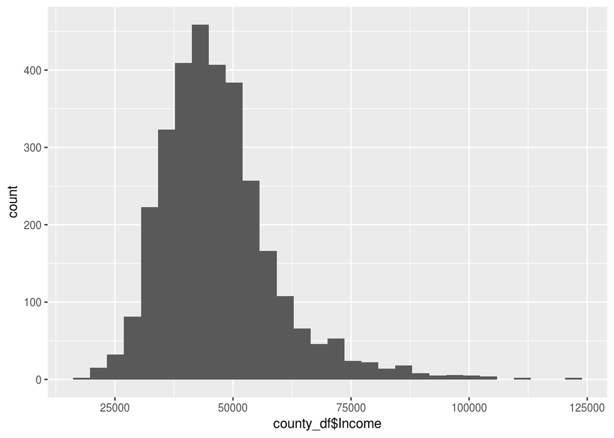

```r
ggplot(data = county_df) + geom_histogram(bins = 30, mapping = aes(x = county_df$Income))
```

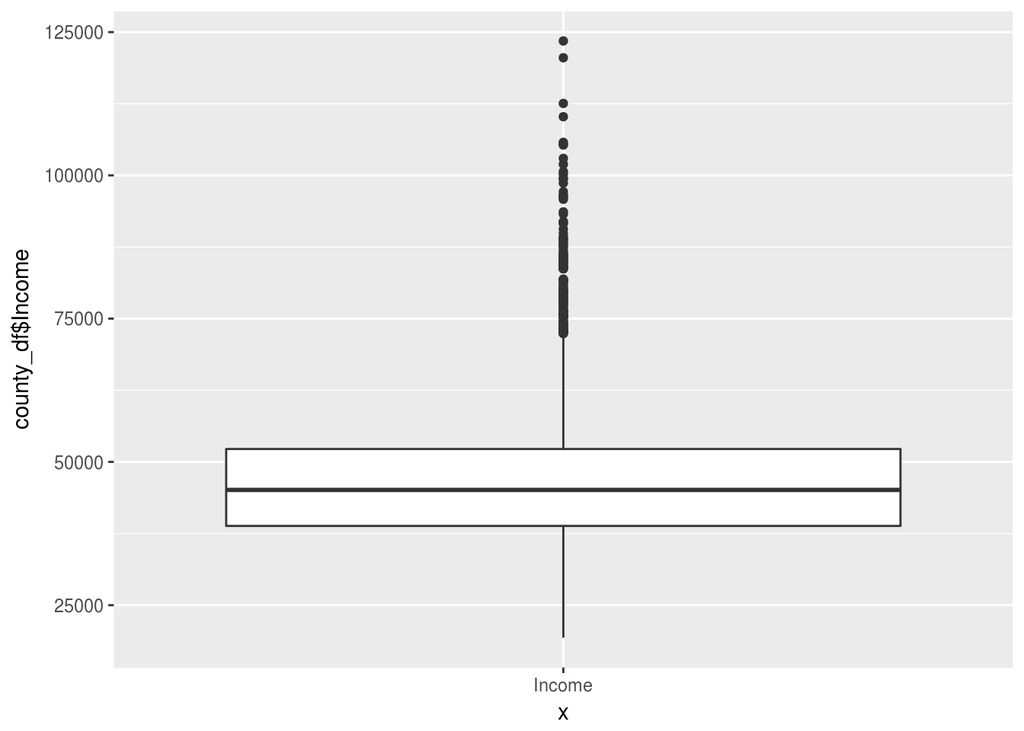

```r
ggplot(data = county_df) + geom_boxplot(mapping = aes(x = "Income", y = county_df$Income))
```

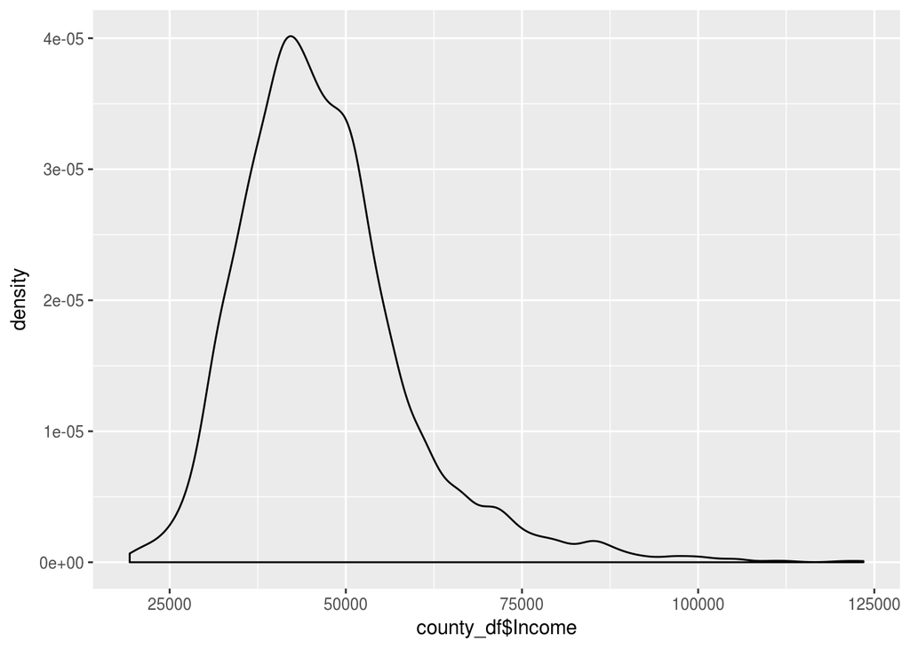

```r
ggplot(data = county_df) + geom_density(mapping = aes(x= county_df$Income))
```

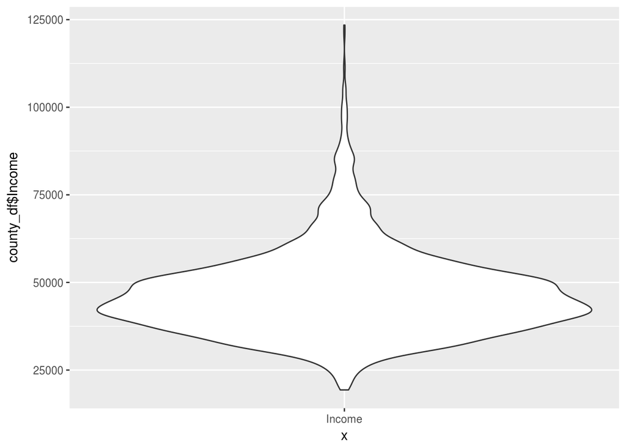

```r
ggplot(data = county_df) + geom_violin(mapping = aes(x = "Income", y = county_df$Income))
```

### Problem 3 - Histogram of total population

Create a histogram of total population for counties in the US.

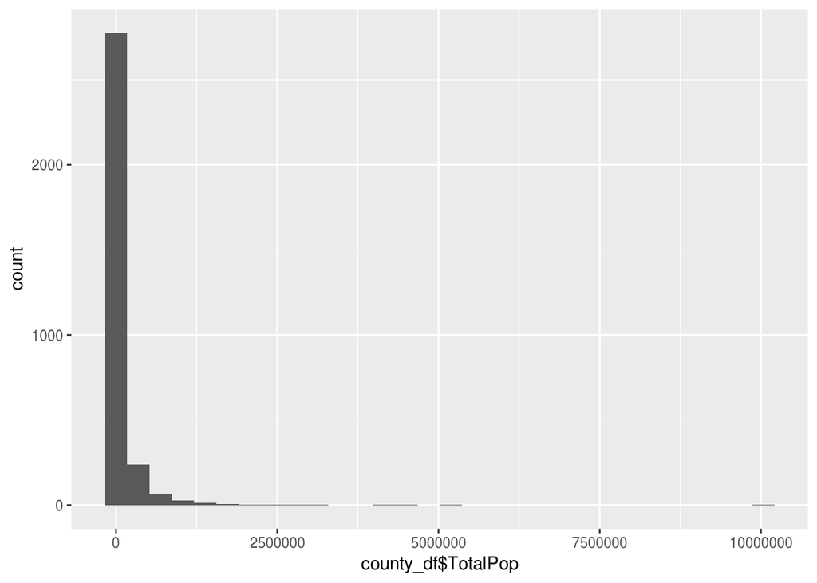

```r
options(scipen=999)
histo_totpop <- ggplot(data = county_df) + geom_histogram(bins = 30, mapping = aes(x = county_df$TotalPop))
histo_totpop
```

Repeat the histogram about but make the following style changes to the plot.

- Add a title such as “Distribution of population for US counties”
- Change y-axis label to “Number of counties”
- Change x-axis label to “Total Population”
- Change the colors of the bars to something other than the default black

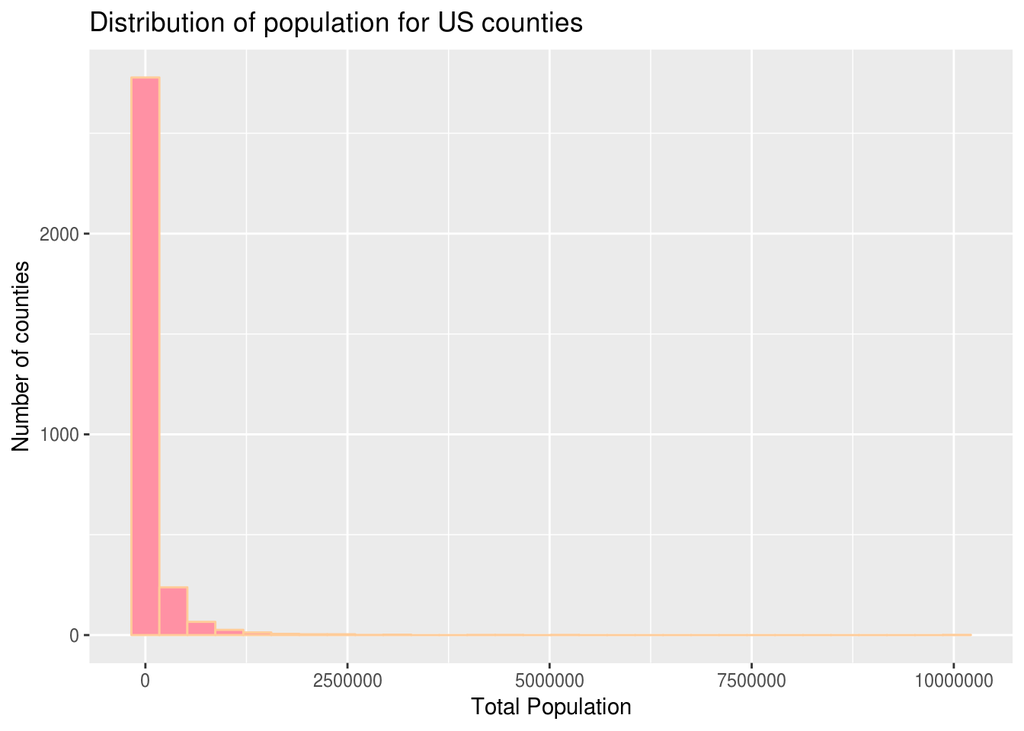

```r
histo_stylechanges <- ggplot(data = county_df) + geom_histogram(bins = 30, mapping = aes(x = county_df$TotalPop) , color = '#FFCC99', fill = '#FF91A4') + ggtitle("Distribution of population for US counties") + labs(y= "Number of counties", x = "Total Population", colour = county_df$TotalPop)

histo_stylechanges
```

**Hacker Extra** - Also create a kernel density plot overlaid on a histogram of Income.

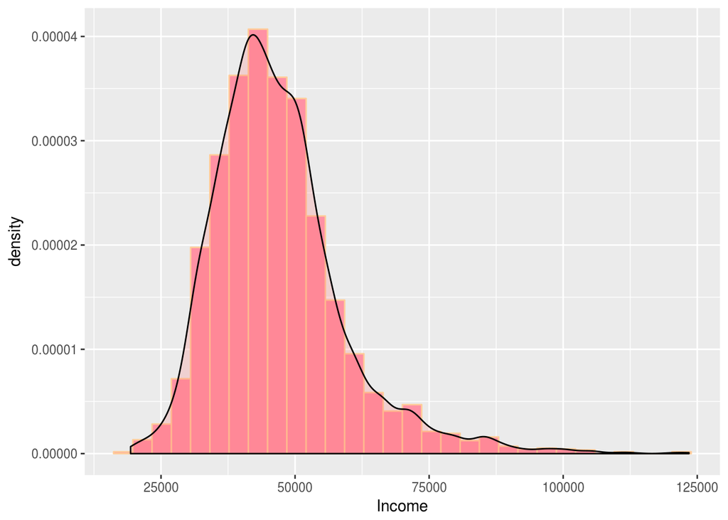

```r
histoden <- ggplot(county_df, aes(x=county_df$Income)) + geom_histogram(bins = 30, aes(x=county_df$Income, y = ..density..), fill = "#FF91A4", colour = "#FFCC99") + geom_density(alpha=.2, fill="#FF6666", colour = "black") + labs( x = "Income")
histoden
```

Repeat the histogram but only for counties with less than 2.5 million people.

```r
county2.5 <- county_df %>% select (County, TotalPop, Income) %>% group_by(County) %>% filter(TotalPop < 2500000)
county2.5
```

```
## # A tibble: 3,134 x 3
## # Groups:   County [1,847]
##    County   TotalPop Income
##    <fct>       <int>  <int>
##  1 Etowah     103766  39220
##  2 Winston     24130  33194
##  3 Escambia    37935  32330
##  4 Autauga     55221  51281
##  5 Baldwin    195121  50254
##  6 Barbour     26932  32964
##  7 Bibb        22604  38678
##  8 Blount      57710  45813
##  9 Bullock     10678  31938
## 10 Butler      20354  32229
## # ... with 3,124 more rows
```

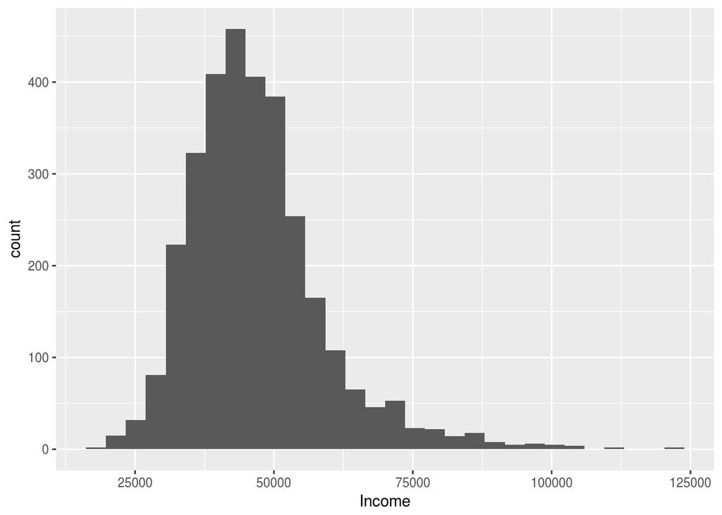

```r
histo_lt2.5m <- ggplot(data = county2.5) + geom_histogram (bins = 30, mapping = aes(x = county2.5$Income)) + labs( x = "Income")
histo_lt2.5m
```